# Clasificacion de imagenes con Clustering Manual

## Librerias

```python
import cv2
import numpy as np
import pandas as pd
import os
from sklearn.preprocessing import StandardScaler
from scipy.cluster.hierarchy import dendrogram, linkage
import matplotlib.pyplot as plt
import random
```

En esta parte del código importo las librerías necesarias para el desarrollo del proyecto. *Utilizo `cv2` de OpenCV para el procesamiento de imágenes, como lectura, redimensionamiento y conversión a escala de grises. *Importo `numpy` como `np` para manejar arreglos y realizar operaciones matemáticas eficientes, y `pandas` como `pd` para estructurar y visualizar datos en forma de tablas. *También uso `os` para interactuar con el sistema de archivos, permitiéndome acceder a carpetas y leer múltiples imágenes. *Desde scikit-learn importo `StandardScaler`, el cual me sirve para normalizar los datos y asegurar que todas las variables tengan la misma escala. *Además, utilizo `dendrogram` y `linkage` de SciPy para aplicar clustering jerárquico y visualizar las relaciones entre los datos. Finalmente, importo `matplotlib.pyplot` como `plt` para generar gráficas que me permiten analizar visualmente los resultados.

## 1. Base de Datos

En este laboratorio se utilizó un subconjunto del dataset **Fashion MNIST**, enfocado en tres categorías específicas: bolsos, pantalones y zapatos. Cada una de estas clases cuenta con aproximadamente 5698 imágenes, para un total considerable de datos disponibles, aunque en el procesamiento se seleccionó una parte representativa para el entrenamiento y análisis. Las imágenes están organizadas en carpetas separadas por clase (`dataset/bolso`, `dataset/pantalon`, `dataset/zapatos`), lo que facilita su manejo y etiquetado. Todas las imágenes fueron normalizadas a un tamaño de 128x128 píxeles durante el preprocesamiento, y corresponden a imágenes de objetos de moda con fondo relativamente uniforme, lo que permite destacar las formas principales. En cuanto a las características visuales, los bolsos presentan estructuras compactas con asas y formas irregulares, los pantalones tienen una forma alargada y simétrica verticalmente, mientras que los zapatos muestran bordes curvos y estructuras más complejas asociadas a la suela. Estas diferencias visuales son fundamentales para que los descriptores puedan distinguir correctamente entre las clases.

## 2. Documentación de la Selección de los Kernels y Descriptores

```python
# FILTROS SOBEL

sobel_Pau_x = np.array([
    [-1,0,1],
    [-2,0,2],
    [-1,0,1]
],dtype=np.float64)

sobel_Pau_y = np.array([
    [-1,-2,-1],
    [0,0,0],
    [1,2,1]
],dtype=np.float64)

# FUNCION DESCRIPTOR

def descriptor_samu(img):

    img = cv2.resize(img,(128,128))
    gris = cv2.cvtColor(img,cv2.COLOR_BGR2GRAY)

    _, mask = cv2.threshold(gris,16,255,cv2.THRESH_BINARY)
    pix = gris[mask==255]

    if len(pix)==0:
        pix = gris.flatten()

    prom = np.mean(pix)
    var = np.var(pix)
    std = np.std(pix)

    area = np.sum(mask==255)

    contornos,_ = cv2.findContours(mask,cv2.RETR_EXTERNAL,cv2.CHAIN_APPROX_SIMPLE)
    peri = sum(cv2.arcLength(c,True) for c in contornos)

    gx = cv2.filter2D(gris.astype(np.float64),cv2.CV_64F,sobel_Pau_x)
    gy = cv2.filter2D(gris.astype(np.float64),cv2.CV_64F,sobel_Pau_y)

    grad = np.mean(np.sqrt(gx**2 + gy**2))

    hist = cv2.calcHist([gris],[0],None,[256],[0,256])
    hist = hist/np.sum(hist)
    entro = -np.sum(hist*np.log2(hist+1e-7))

    return np.array([prom,var,std,area,peri,grad,entro])
```

En este proyecto se seleccionaron filtros de Sobel para la detección de bordes, los cuales permiten identificar cambios bruscos de intensidad en las imágenes. Específicamente, se utilizaron dos kernels: el Sobel en dirección horizontal (X) representado por (\begin{bmatrix}-1 & 0 & 1 \\ -2 & 0 & 2 \\ -1 & 0 & 1\end{bmatrix}) y el Sobel en dirección vertical (Y) representado por (\begin{bmatrix}-1 & -2 & -1 \\ 0 & 0 & 0 \\ 1 & 2 & 1\end{bmatrix}). Estos filtros tienen como objetivo resaltar los bordes en diferentes orientaciones, lo cual es fundamental para capturar la forma de los objetos. A partir de estos filtros se calcula el gradiente, que mide la intensidad promedio de los bordes y aporta información de textura.

Adicionalmente, se diseñó un conjunto de descriptores estadísticos y geométricos que permiten caracterizar cada imagen. El promedio mide la intensidad media de los píxeles, la varianza y la desviación estándar cuantifican la dispersión de los niveles de gris, el área representa la cantidad de píxeles relevantes del objeto, y el perímetro mide la longitud de sus contornos, lo que permite capturar su forma. Por otro lado, el gradiente obtenido con Sobel describe la presencia de bordes, y la entropía mide el nivel de información o complejidad de la imagen. En conjunto, estos descriptores permiten diferenciar las clases analizadas, ya que cada tipo de objeto (bolso, pantalón y zapato) presenta patrones distintos en términos de forma, textura y distribución de intensidades.

## 3.Extracción de características

En este proyecto, la extracción de características se realiza mediante la función `descriptor_samu`, donde a cada imagen se le aplican diferentes operaciones de procesamiento para obtener un vector numérico representativo. En esta función, primero se redimensiona la imagen a 128x128 píxeles y se convierte a escala de grises. Luego, se aplica una umbralización para segmentar el objeto principal y trabajar únicamente con los píxeles relevantes. A partir de estos píxeles se calculan descriptores estadísticos como el promedio, la varianza y la desviación estándar, así como descriptores geométricos como el área y el perímetro. Adicionalmente, se aplican filtros de Sobel para obtener el gradiente y medir la intensidad de los bordes, y se calcula la entropía para cuantificar la información de la imagen. Todo esto se devuelve en forma de un vector de características.

Posteriormente, estos descriptores se organizan en una matriz de datos durante la carga del dataset mediante la función `cargar_datos`, donde cada fila corresponde a una imagen y cada columna a una característica. Finalmente, todas las clases se combinan en una sola matriz utilizando `np.vstack`, lo que permite trabajar con todo el conjunto de datos de forma estructurada para el proceso de clustering y clasificación.

## CARGAR DATOS

```python
def cargar_datos(ruta,lim=30):

    archivos = sorted(os.listdir(ruta))
    datos = []

    for nombre in archivos[:lim]:

        img = cv2.imread(os.path.join(ruta,nombre))

        if img is not None:
            datos.append(descriptor_samu(img))

    return np.array(datos)


bolsos_Pau = cargar_datos("dataset/bolso",100)
pantalones_Samu = cargar_datos("dataset/pantalon",100)
zapatos_Pau = cargar_datos("dataset/zapatos",100)

print("Datos cargados:",len(bolsos_Pau),len(pantalones_Samu),len(zapatos_Pau))
```

```
Datos cargados: 100 100 100
```

En esta parte del código defino una función para cargar y procesar automáticamente un conjunto de imágenes desde una carpeta. Primero obtengo la lista de archivos usando `os.listdir` y los ordeno para mantener consistencia en el procesamiento. Luego recorro solo una cantidad limitada de imágenes (`lim`) para controlar el tamaño del dataset. En cada iteración leo la imagen con `cv2.imread` de OpenCV y verifico que se haya cargado correctamente. Si es válida, aplico la función `descriptor_samu` para extraer sus características y las guardo en una lista. Al final convierto esa lista en un arreglo de `numpy`, lo que me facilita trabajar matemáticamente con los datos. Después utilizo esta función para cargar tres clases diferentes (bolsos, pantalones y zapatos), cada una con hasta 100 imágenes, y finalmente imprimo la cantidad de datos cargados para verificar que todo se haya realizado correctamente.

## NORMALIZAR

```python
todo = np.vstack((bolsos_Pau,pantalones_Samu,zapatos_Pau))

scaler = StandardScaler()
todo = scaler.fit_transform(todo)

todo[:,3] *= 1.5
todo[:,4] *= 2.5
todo[:,5] *= 2.5

n_b = len(bolsos_Pau)
n_p = len(pantalones_Samu)

y_real = np.array(
["Bolso"]*n_b +
["Pantalon"]*n_p +
["Zapatos"]*(len(todo)-n_b-n_p)
)
```

## 3.Normalización

Adicionalmente, se realiza un ajuste manual de pesos multiplicando ciertas columnas del vector de características: el área se multiplica por 1.5, mientras que el perímetro y el gradiente se multiplican por 2.5. Esta ponderación se realiza porque estas características contienen información relevante sobre la forma y los bordes de los objetos, lo que ayuda a mejorar la separación entre clases. En conjunto, la normalización y el ajuste de pesos permiten que el modelo sea más sensible a las características más discriminativas, mejorando así el rendimiento del clustering y la clasificación.

## 4. Clustering Jerárquico Manual

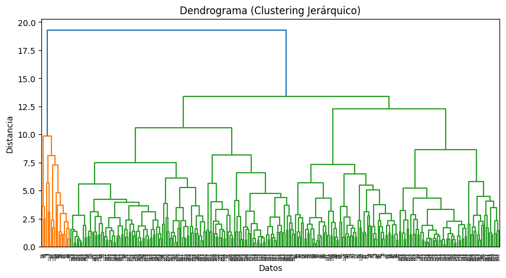

```
Clusters finales: 3

Distribución:
Grupo 0: {np.str_('Bolso'): np.int64(17), np.str_('Pantalon'): np.int64(2)}
Grupo 1: {np.str_('Bolso'): np.int64(17), np.str_('Pantalon'): np.int64(53), np.str_('Zapatos'): np.int64(77)}
Grupo 2: {np.str_('Bolso'): np.int64(66), np.str_('Pantalon'): np.int64(45), np.str_('Zapatos'): np.int64(23)}
```

```python
def distancia_Pau(a,b):
    return np.sqrt(np.sum((a-b)**2))

def distancia_grupos(grupo1,grupo2):

    dist_max = 0

    for p in grupo1:
        for q in grupo2:

            d = distancia_Pau(p,q)

            if d > dist_max:
                dist_max = d

    return dist_max

# DENDROGRAMA

Z = linkage(todo, method='complete')

plt.figure(figsize=(10,5))
dendrogram(Z)
plt.title("Dendrograma (Clustering Jerárquico)")
plt.xlabel("Datos")
plt.ylabel("Distancia")

plt.show()

clusters_Samu = [[i] for i in range(len(todo))]

while len(clusters_Samu) > 3:

    mejor = float("inf")
    pos1,pos2 = -1,-1

    for i in range(len(clusters_Samu)):
        for j in range(i+1,len(clusters_Samu)):

            g1 = todo[clusters_Samu[i]]
            g2 = todo[clusters_Samu[j]]

            d = distancia_grupos(g1,g2)

            if d < mejor:
                mejor = d
                pos1,pos2 = i,j

    nuevo = clusters_Samu[pos1] + clusters_Samu[pos2]

    clusters_Samu.pop(max(pos1,pos2))
    clusters_Samu.pop(min(pos1,pos2))
    clusters_Samu.append(nuevo)

print("\nClusters finales:",len(clusters_Samu))



print("\nDistribución:")

for i,grupo in enumerate(clusters_Samu):

    etiquetas = []

    for idx in grupo:
        if idx < n_b:
            etiquetas.append("Bolso")
        elif idx < n_b + n_p:
            etiquetas.append("Pantalon")
        else:
            etiquetas.append("Zapatos")

    val,cont = np.unique(etiquetas,return_counts=True)

    print(f"Grupo {i}:", dict(zip(val,cont)))
```

### 5. Clustering Jerárquico e Interpretación del Dendrograma

En este proyecto se utilizó un método de clustering jerárquico de tipo **aglomerativo**, lo que significa que inicialmente cada dato comienza como un cluster individual y, a medida que avanza el algoritmo, los clusters se van fusionando progresivamente según su similitud. La métrica de distancia empleada fue la **distancia euclidiana**, definida como ( d = \sqrt{\sum (x_i - y_i)^2} ), la cual mide la separación entre dos puntos en el espacio de características. Además, se utilizó el criterio de enlace **complete linkage**, en el cual la distancia entre dos grupos se define como la máxima distancia entre todos los pares de puntos pertenecientes a ambos grupos, lo que tiende a formar clusters más compactos y bien separados.

El dendrograma es una representación gráfica en forma de árbol que muestra cómo se van agrupando los datos en cada iteración del algoritmo. En el eje horizontal se encuentran las muestras (imágenes), mientras que en el eje vertical se representa la distancia a la cual se fusionan los clusters. Cada unión horizontal indica el momento en que dos grupos se combinan, y la altura de esa unión refleja qué tan diferentes eran antes de unirse.

Finalmente, el dendrograma permite decidir de manera visual cuántos clusters formar, observando los saltos grandes en la distancia (espacios verticales amplios). Estos saltos indican que se están uniendo grupos muy diferentes, por lo que cortar antes de esos puntos suele ser una buena elección para obtener clusters bien definidos.

## Explicacion paso a paso

  ```
  for p in grupo1:
      for q in grupo2:
          d = distancia_Pau(p,q)
          if d > dist_max:
              dist_max = d
  ```

## CENTROIDES

```python
bolsos_Pau = todo[:n_b]
pantalones_Samu = todo[n_b:n_b+n_p]
zapatos_Pau = todo[n_b+n_p:]

centro_b = np.mean(bolsos_Pau,axis=0)
centro_p = np.mean(pantalones_Samu,axis=0)
centro_z = np.mean(zapatos_Pau,axis=0)
```

En esta parte del código calculo los centroides de cada clase (bolsos, pantalones y zapatos) a partir de los datos ya normalizados. Primero separo nuevamente el conjunto total `todo` en tres subconjuntos utilizando los índices correspondientes a cada categoría. Luego, para cada grupo, calculo el promedio de sus características usando `np.mean` a lo largo del eje 0, lo que me permite obtener un vector representativo de cada clase. Estos centroides (`centro_b`, `centro_p`, `centro_z`) funcionan como puntos centrales en el espacio de características y resumen el comportamiento típico de cada categoría. Posteriormente, estos valores serán utilizados para clasificar nuevos datos comparando qué tan cerca están de cada centroide.

# CLASIFICACION

```python
def clasificar(x):

    d1 = distancia_Pau(x,centro_b)
    d2 = distancia_Pau(x,centro_p)
    d3 = distancia_Pau(x,centro_z)

    return min(
        {"Bolso":d1,"Pantalon":d2,"Zapatos":d3},
        key=lambda k: {"Bolso":d1,"Pantalon":d2,"Zapatos":d3}[k]
    )
```

# MATRIZ DE CONFUSION

```python
mat = np.zeros((3,3))
clases = ["Bolso","Pantalon","Zapatos"]

for i in range(len(todo)):

    x = todo[i]
    real = y_real[i]

    pred = clasificar(x)

    f = clases.index(real)
    c = clases.index(pred)

    mat[f][c] += 1

df_val = pd.DataFrame(mat,index=clases,columns=clases)

print("\nMatriz (valores)")
print(df_val)

# MATRIZ %

porc = mat / mat.sum(axis=1,keepdims=True) * 100

df_por = pd.DataFrame(porc,index=clases,columns=clases)

print("\nMatriz (%)")
print(df_por.round(2))
```

```
Matriz (valores)
          Bolso  Pantalon  Zapatos
Bolso      84.0       7.0      9.0
Pantalon    8.0      74.0     18.0
Zapatos     0.0      23.0     77.0

Matriz (%)
          Bolso  Pantalon  Zapatos
Bolso      84.0       7.0      9.0
Pantalon    8.0      74.0     18.0
Zapatos     0.0      23.0     77.0
```

En esta sección evalúo el desempeño del clasificador utilizando una matriz de confusión. Primero creo una matriz de ceros de tamaño 3x3, donde las filas representan las clases reales (Bolso, Pantalón, Zapatos) y las columnas las clases predichas. Luego recorro todos los datos del conjunto `todo`; para cada muestra obtengo su etiqueta real (`y_real[i]`) y calculo su predicción usando la función `clasificar(x)`. Después convierto esas etiquetas en índices de fila y columna, y aumento en 1 la posición correspondiente dentro de la matriz. De esta forma voy contabilizando cuántas veces cada clase fue correctamente o incorrectamente clasificada. Posteriormente convierto la matriz en un `DataFrame` de `pandas` para visualizarla más claramente. Luego calculo la versión en porcentaje dividiendo cada fila por el total de sus elementos, lo que me permite interpretar los resultados de forma relativa (por ejemplo, qué porcentaje de bolsos fue correctamente clasificado). Finalmente imprimo ambas matrices, lo que me da una visión completa del rendimiento del modelo tanto en valores absolutos como en porcentajes.

# ACCURACY

```python
# ACCURACY

acc = np.trace(mat)/np.sum(mat)*100
print("\nAccuracy:",round(acc,2),"%")
```

```
Accuracy: 78.33 %
```

En esta parte del código calculo la métrica de *accuracy* para evaluar el rendimiento global del clasificador. Para ello utilizo la matriz de confusión previamente construida (`mat`). La función `np.trace(mat)` me permite obtener la suma de los elementos de la diagonal principal, que corresponden a las clasificaciones correctas (cuando la clase real coincide con la predicha). Luego divido este valor entre la suma total de todos los elementos de la matriz (`np.sum(mat)`), que representa el número total de muestras evaluadas. Finalmente multiplico por 100 para expresar el resultado en porcentaje. Este valor de accuracy indica qué tan bien está funcionando el modelo en general, mostrando el porcentaje total de aciertos sobre todas las predicciones realizadas.

## Mostrar imagenes

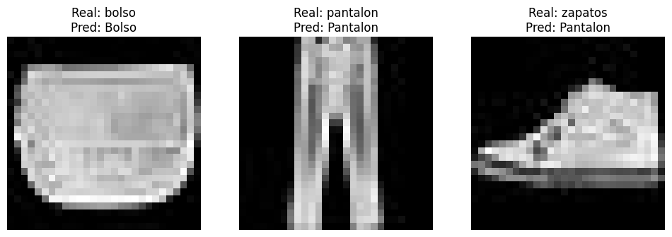

```python
def mostrar_imagenes():

    clases = ["bolso","pantalon","zapatos"]

    plt.figure(figsize=(12,6))

    for i,clase in enumerate(clases):

        ruta = f"dataset/{clase}"
        img_name = random.choice(os.listdir(ruta))

        img = cv2.imread(os.path.join(ruta,img_name))
        img_rgb = cv2.cvtColor(img, cv2.COLOR_BGR2RGB)

        x = descriptor_samu(img)
        x = scaler.transform([x])[0]
        pred = clasificar(x)

        plt.subplot(1,3,i+1)
        plt.imshow(img_rgb)
        plt.title(f"Real: {clase}\nPred: {pred}")
        plt.axis("off")

    plt.show()

mostrar_imagenes()
```

### 6.Métricas de evaluación del clustering

Para evaluar la calidad del agrupamiento obtenido, se utilizó el índice de Silhouette, el cual mide qué tan similar es cada punto a su propio cluster en comparación con otros clusters. Este índice toma valores entre -1 y 1, donde valores cercanos a 1 indican que los datos están bien agrupados, valores cercanos a 0 indican solapamiento entre clusters, y valores negativos sugieren una mala asignación.

El índice se calculó a partir de las etiquetas generadas por el clustering jerárquico, permitiendo cuantificar la cohesión interna de los grupos y la separación entre ellos. Un valor alto de Silhouette indica que las características extraídas y el método de clustering utilizado logran diferenciar adecuadamente las clases de bolsos, pantalones y zapatos.

```python
from sklearn.metrics import silhouette_score

# convertir clusters a labels
labels_cluster = np.zeros(len(todo))

for i, grupo in enumerate(clusters_Samu):
    for idx in grupo:
        labels_cluster[idx] = i

# calcular silhouette
sil = silhouette_score(todo, labels_cluster)

print("\nIndice de Silhouette:", round(sil,4))
```

```
Indice de Silhouette: 0.2304
```

### Interpretación del Índice de Silhouette

El índice de Silhouette obtenido fue de **0.2304**, lo cual indica que el clustering presenta una **separación moderada entre los grupos**, pero no completamente definida. Este índice toma valores entre -1 y 1, donde valores cercanos a 1 representan clusters bien separados, valores cercanos a 0 indican que los clusters se solapan, y valores negativos reflejan una mala asignación de los datos.

Para mejorar este resultado, se podrían considerar estrategias como el uso de descriptores más discriminativos, ajuste de los pesos aplicados a las características, o la implementación de técnicas adicionales de preprocesamiento que permitan resaltar mejor las diferencias entre clases.

## 8. Discusión

Entre las ventajas del clustering jerárquico se destaca su capacidad de visualización mediante el dendrograma y su independencia de parámetros iniciales como el número de clusters. Sin embargo, su principal desventaja es el costo computacional y la dificultad para manejar grandes volúmenes de datos. En contraste, DBSCAN permite detectar outliers de manera natural, pero requiere una cuidadosa selección de parámetros.

## Conclusiones

A partir del desarrollo de este laboratorio puedo concluir que el uso de descriptores bien diseñados permite representar adecuadamente imágenes mediante características numéricas que capturan información estadística, geométrica y de textura. La normalización de los datos y la asignación de pesos a ciertas variables resultaron fundamentales para mejorar la separación entre clases, evidenciando la importancia del preprocesamiento en problemas de clasificación.

Finalmente, la implementación de un clasificador basado en centroides demostró ser una estrategia sencilla pero efectiva para asignar nuevas muestras a una clase, y su evaluación mediante la matriz de confusión y el accuracy permitió cuantificar el desempeño del modelo. En conjunto, el proyecto evidencia cómo la combinación de procesamiento de imágenes, extracción de características y técnicas de aprendizaje automático permite resolver problemas de clasificación de manera clara y estructurada.